# Example: Parkinson’s disease

```r
library(multinma)
options(mc.cores = parallel::detectCores())
```

This vignette describes the analysis of data on the mean off-time reduction in patients given dopamine agonists as adjunct therapy in Parkinson’s disease, in a network of 7 trials of 4 active drugs plus placebo (Dias et al. 2011). The data are available in this package as `parkinsons`:

```r
head(parkinsons)
```

```
#>   studyn trtn     y    se   n  diff se_diff
#> 1      1    1 -1.22 0.504  54    NA   0.504
#> 2      1    3 -1.53 0.439  95 -0.31   0.668
#> 3      2    1 -0.70 0.282 172    NA   0.282
#> 4      2    2 -2.40 0.258 173 -1.70   0.382
#> 5      3    1 -0.30 0.505  76    NA   0.505
#> 6      3    2 -2.60 0.510  71 -2.30   0.718
```

We consider analysing these data in three separate ways:

1. Using arm-based data (means `y` and corresponding standard errors `se`);
2. Using contrast-based data (mean differences `diff` and corresponding standard errors `se_diff`);
3. A combination of the two, where some studies contribute arm-based data, and other contribute contrast-based data.

## Analysis of arm-based data

We begin with an analysis of the arm-based data - means and standard errors.

### Setting up the network

We have arm-level continuous data giving the mean off-time reduction (`y`) and standard error (`se`) in each arm. We use the function `set_agd_arm()` to set up the network.

```r
arm_net <- set_agd_arm(parkinsons,
                      study = studyn,
                      trt = trtn,
                      y = y,
                      se = se,
                      sample_size = n)
arm_net
```

```
#> A network with 7 AgD studies (arm-based).
#>
#> ------------------------------------------------------- AgD studies (arm-based) ----
#>  Study Treatment arms
#>  1     2: 1 | 3
#>  2     2: 1 | 2
#>  3     3: 4 | 1 | 2
#>  4     2: 4 | 3
#>  5     2: 4 | 3
#>  6     2: 4 | 5
#>  7     2: 4 | 5
#>
#>  Outcome type: continuous
#> ------------------------------------------------------------------------------------
#> Total number of treatments: 5
#> Total number of studies: 7
#> Reference treatment is: 4
#> Network is connected
```

We let treatment 4 be set by default as the network reference treatment, since this results in considerably improved sampling efficiency over choosing treatment 1 as the network reference. The `sample_size` argument is optional, but enables the nodes to be weighted by sample size in the network plot.

Plot the network structure.

```r
plot(arm_net, weight_edges = TRUE, weight_nodes = TRUE)
```

[output not shown]

### Meta-analysis models

We fit both fixed effect (FE) and random effects (RE) models.

#### Fixed effect meta-analysis

```r
summary(normal(scale = 100))
```

```
#> A Normal prior distribution: location = 0, scale = 100.
#> 50% of the prior density lies between -67.45 and 67.45.
#> 95% of the prior density lies between -196 and 196.
```

The model is fitted using the `nma()` function.

```r
arm_fit_FE <- nma(arm_net,
                  trt_effects = "fixed",
                  prior_intercept = normal(scale = 100),
                  prior_trt = normal(scale = 10))
```

```
#> Note: Setting "4" as the network reference treatment.
```

Basic parameter summaries are given by the `print()` method:

```r
arm_fit_FE
```

```
#> A fixed effects NMA with a normal likelihood (identity link).
#> Inference for Stan model: normal.
#> 4 chains, each with iter=2000; warmup=1000; thin=1;
#> post-warmup draws per chain=1000, total post-warmup draws=4000.
#>
#>       mean se_mean   sd   2.5%   25%   50%   75% 97.5% n_eff Rhat
#> d[1]  0.52    0.01 0.48  -0.41  0.19  0.53  0.84  1.47  1554    1
#> d[2] -1.28    0.01 0.52  -2.30 -1.64 -1.28 -0.93 -0.27  1461    1
#> d[3]  0.04    0.01 0.33  -0.59 -0.19  0.04  0.27  0.66  1791    1
#> d[5] -0.30    0.00 0.21  -0.71 -0.44 -0.30 -0.16  0.13  2891    1
#> lp__ -6.69    0.06 2.38 -12.27 -8.05 -6.37 -4.95 -3.04  1581    1
#>
#> Samples were drawn using NUTS(diag_e) at Mon Apr 29 16:39:50 2024.
#> For each parameter, n_eff is a crude measure of effective sample size,
#> and Rhat is the potential scale reduction factor on split chains (at
#> convergence, Rhat=1).
```

By default, summaries of the study-specific intercepts $\mu_j$ are hidden, but could be examined by changing the `pars` argument:

```r
# Not run
print(arm_fit_FE, pars = c("d", "mu"))
```

The prior and posterior distributions can be compared visually using the `plot_prior_posterior()` function:

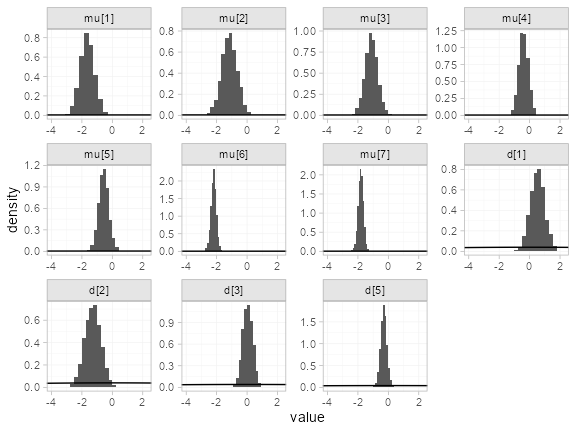

```r
plot_prior_posterior(arm_fit_FE)
```

#### Random effects meta-analysis

```r
summary(normal(scale = 100))
```

```
#> A Normal prior distribution: location = 0, scale = 100.
#> 50% of the prior density lies between -67.45 and 67.45.
#> 95% of the prior density lies between -196 and 196.
```

```r
summary(half_normal(scale = 5))
```

```
#> A half-Normal prior distribution: location = 0, scale = 5.
#> 50% of the prior density lies between 0 and 3.37.
#> 95% of the prior density lies between 0 and 9.8.
```

Fitting the RE model

```r
arm_fit_RE <- nma(arm_net,
                  seed = 379394727,
                  trt_effects = "random",
                  prior_intercept = normal(scale = 100),
                  prior_trt = normal(scale = 100),
                  prior_het = half_normal(scale = 5),
                  adapt_delta = 0.99)
```

```
#> Note: Setting "4" as the network reference treatment.
#> Warning: There were 3 divergent transitions after warmup. See
#> https://mc-stan.org/misc/warnings.html#divergent-transitions-after-warmup
#> to find out why this is a problem and how to eliminate them.
#> Warning: Examine the pairs() plot to diagnose sampling problems
```

We do see a small number of divergent transition errors, which cannot simply be removed by increasing the value of the `adapt_delta` argument (by default set to `0.95` for RE models). To diagnose, we use the `pairs()` method to investigate where in the posterior distribution these divergences are happening (indicated by red crosses):

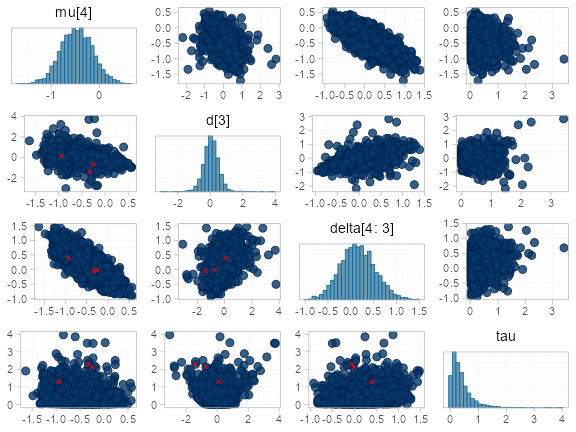

```r
pairs(arm_fit_RE, pars = c("mu[4]", "d[3]", "delta[4: 3]", "tau"))
```

The divergent transitions occur in the upper tail of the heterogeneity standard deviation. In this case, with only a small number of studies, there is not very much information to estimate the heterogeneity standard deviation and the prior distribution may be too heavy-tailed. We could consider a more informative prior distribution for the heterogeneity variance to aid estimation.

Basic parameter summaries are given by the `print()` method:

```r
arm_fit_RE
```

```
#> A random effects NMA with a normal likelihood (identity link).
#> Inference for Stan model: normal.
#> 4 chains, each with iter=2000; warmup=1000; thin=1;
#> post-warmup draws per chain=1000, total post-warmup draws=4000.
#>
#>        mean se_mean   sd   2.5%    25%    50%    75% 97.5% n_eff Rhat
#> d[1]   0.55    0.02 0.66  -0.65   0.16   0.53   0.93  1.77  1437    1
#> d[2]  -1.31    0.02 0.71  -2.69  -1.74  -1.31  -0.89  0.00  1628    1
#> d[3]   0.04    0.01 0.50  -0.91  -0.25   0.04   0.33  0.97  1636    1
#> d[5]  -0.31    0.01 0.46  -1.26  -0.51  -0.29  -0.09  0.59  2024    1
#> lp__ -12.83    0.10 3.60 -20.63 -15.03 -12.50 -10.23 -6.88  1380    1
#> tau    0.40    0.02 0.40   0.01   0.13   0.29   0.52  1.49   618    1
#>
#> Samples were drawn using NUTS(diag_e) at Mon Apr 29 16:40:01 2024.
#> For each parameter, n_eff is a crude measure of effective sample size,
#> and Rhat is the potential scale reduction factor on split chains (at
#> convergence, Rhat=1).
```

By default, summaries of the study-specific intercepts $\mu_j$ and study-specific relative effects $\delta_{jk}$ are hidden, but could be examined by changing the `pars` argument:

```r
# Not run
print(arm_fit_RE, pars = c("d", "mu", "delta"))
```

The prior and posterior distributions can be compared visually using the `plot_prior_posterior()` function:

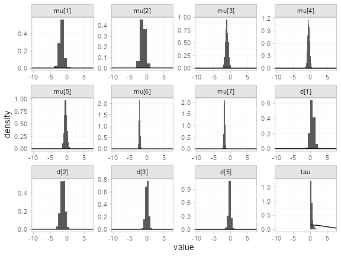

```r
plot_prior_posterior(arm_fit_RE)
```

#### Model comparison

Model fit can be checked using the `dic()` function:

```r
(arm_dic_FE <- dic(arm_fit_FE))
```

```
#> Residual deviance: 13.4 (on 15 data points)
#>                pD: 11.1
#>               DIC: 24.4
```

```r
(arm_dic_RE <- dic(arm_fit_RE))
```

```
#> Residual deviance: 13.7 (on 15 data points)
#>                pD: 12.6
#>               DIC: 26.3
```

Both models fit the data well, having posterior mean residual deviance close to the number of data points. The DIC is similar between models, so we choose the FE model based on parsimony.

We can also examine the residual deviance contributions with the corresponding `plot()` method.

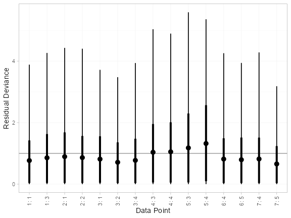

```r
plot(arm_dic_FE)
```

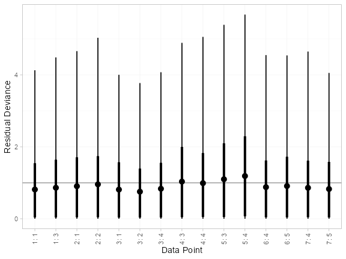

```r
plot(arm_dic_RE)
```

### Further results

For comparison with Dias et al. (2011), we can produce relative effects against placebo using the `relative_effects()` function with `trt_ref = 1`:

```r
(arm_releff_FE <- relative_effects(arm_fit_FE, trt_ref = 1))
```

```
#>       mean   sd  2.5%   25%   50%   75% 97.5% Bulk_ESS Tail_ESS Rhat
#> d[4] -0.52 0.48 -1.47 -0.84 -0.53 -0.19  0.41     1561     2426    1
#> d[2] -1.81 0.32 -2.46 -2.02 -1.81 -1.59 -1.19     5125     2917    1
#> d[3] -0.48 0.49 -1.44 -0.81 -0.48 -0.15  0.47     2416     2508    1
#> d[5] -0.82 0.53 -1.86 -1.18 -0.83 -0.47  0.20     1762     1810    1
```

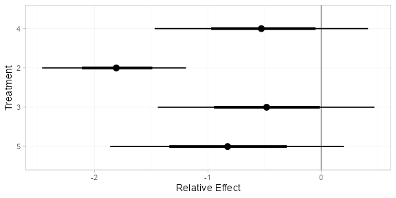

```r
plot(arm_releff_FE, ref_line = 0)
```

```r
(arm_releff_RE <- relative_effects(arm_fit_RE, trt_ref = 1))
```

```
#>       mean   sd  2.5%   25%   50%   75% 97.5% Bulk_ESS Tail_ESS Rhat
#> d[4] -0.55 0.66 -1.77 -0.93 -0.53 -0.16  0.65     1498     1706    1
#> d[2] -1.86 0.51 -2.94 -2.15 -1.86 -1.56 -0.87     4005     2430    1
#> d[3] -0.51 0.66 -1.72 -0.90 -0.49 -0.12  0.75     2471     2260    1
#> d[5] -0.85 0.79 -2.37 -1.28 -0.85 -0.41  0.71     1801     1677    1
```

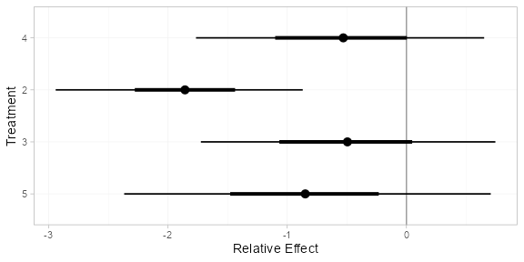

```r
plot(arm_releff_RE, ref_line = 0)
```

Following Dias et al. (2011), we produce absolute predictions of the mean off-time reduction on each treatment assuming a Normal distribution for the outcomes on treatment 1 (placebo) with mean $-0.73$ and precision $21$. We use the `predict()` method, where the `baseline` argument takes a `distr()` distribution object with which we specify the corresponding Normal distribution, and we specify `baseline_trt = 1` to indicate that the baseline distribution corresponds to treatment 1. (Strictly speaking, `type = "response"` is unnecessary here, since the identity link function was used.)

```r
arm_pred_FE <- predict(arm_fit_FE,
                       baseline = distr(qnorm, mean = -0.73, sd = 21^-0.5),
                       type = "response",
                       baseline_trt = 1)
arm_pred_FE
```

```
#>          mean   sd  2.5%   25%   50%   75% 97.5% Bulk_ESS Tail_ESS Rhat
#> pred[4] -1.25 0.53 -2.30 -1.61 -1.25 -0.89 -0.22     1796     2499    1
#> pred[1] -0.73 0.22 -1.16 -0.88 -0.73 -0.58 -0.29     3910     3936    1
#> pred[2] -2.53 0.39 -3.29 -2.80 -2.54 -2.27 -1.77     4640     2825    1
#> pred[3] -1.21 0.53 -2.22 -1.57 -1.21 -0.86 -0.15     2585     2980    1
#> pred[5] -1.55 0.57 -2.68 -1.94 -1.56 -1.16 -0.44     1993     2600    1
```

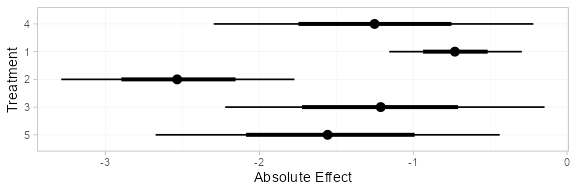

```r
plot(arm_pred_FE)
```

```r
arm_pred_RE <- predict(arm_fit_RE,
                       baseline = distr(qnorm, mean = -0.73, sd = 21^-0.5),
                       type = "response",
                       baseline_trt = 1)
arm_pred_RE
```

```
#>          mean   sd  2.5%   25%   50%   75% 97.5% Bulk_ESS Tail_ESS Rhat
#> pred[4] -1.27 0.69 -2.62 -1.69 -1.26 -0.85  0.05     1650     1667    1
#> pred[1] -0.73 0.22 -1.16 -0.87 -0.73 -0.58 -0.30     3976     3867    1
#> pred[2] -2.59 0.56 -3.68 -2.92 -2.57 -2.25 -1.49     3978     2541    1
#> pred[3] -1.23 0.69 -2.54 -1.66 -1.23 -0.81  0.13     2654     2319    1
#> pred[5] -1.58 0.83 -3.12 -2.05 -1.57 -1.11  0.04     1930     1701    1
```

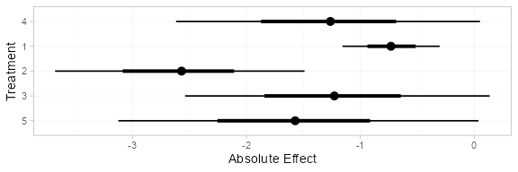

```r
plot(arm_pred_RE)
```

If the `baseline` argument is omitted, predictions of mean off-time reduction will be produced for every study in the network based on their estimated baseline response $\mu_j$:

```r
arm_pred_FE_studies <- predict(arm_fit_FE, type = "response")
arm_pred_FE_studies
```

```
#> ---------------------------------------------------------------------- Study: 1 ----
#>
#>             mean   sd  2.5%   25%   50%   75% 97.5% Bulk_ESS Tail_ESS Rhat
#> pred[1: 4] -1.65 0.47 -2.57 -1.96 -1.66 -1.33 -0.75     2070     2888    1
#> pred[1: 1] -1.12 0.43 -1.95 -1.41 -1.13 -0.84 -0.28     3883     3420    1
#> pred[1: 2] -2.93 0.51 -3.92 -3.28 -2.93 -2.57 -1.96     3903     3458    1
#> pred[1: 3] -1.61 0.40 -2.39 -1.87 -1.60 -1.34 -0.84     4134     3242    1
#> pred[1: 5] -1.95 0.51 -2.97 -2.28 -1.95 -1.60 -0.95     2263     2753    1
#>
#> ---------------------------------------------------------------------- Study: 2 ----
#>
#>             mean   sd  2.5%   25%   50%   75% 97.5% Bulk_ESS Tail_ESS Rhat
#> pred[2: 4] -1.16 0.51 -2.19 -1.50 -1.17 -0.81 -0.20     1462     2235    1
#> pred[2: 1] -0.64 0.26 -1.15 -0.81 -0.64 -0.46 -0.13     4983     3344    1
#> pred[2: 2] -2.44 0.24 -2.92 -2.60 -2.44 -2.28 -1.99     4253     3244    1
#> pred[2: 3] -1.12 0.52 -2.12 -1.47 -1.12 -0.76 -0.10     2389     2725    1
#> pred[2: 5] -1.46 0.55 -2.56 -1.84 -1.46 -1.09 -0.39     1653     2265    1
#>
#> ---------------------------------------------------------------------- Study: 3 ----
#>
#>             mean   sd  2.5%   25%   50%   75% 97.5% Bulk_ESS Tail_ESS Rhat
#> pred[3: 4] -1.11 0.41 -1.94 -1.38 -1.11 -0.83 -0.30     1796     2328    1
#> pred[3: 1] -0.59 0.35 -1.27 -0.83 -0.59 -0.36  0.11     4190     3442    1
#> pred[3: 2] -2.40 0.38 -3.15 -2.65 -2.40 -2.13 -1.65     4199     3486    1
#> pred[3: 3] -1.07 0.46 -1.95 -1.38 -1.07 -0.77 -0.16     2930     2423    1
#> pred[3: 5] -1.41 0.47 -2.33 -1.72 -1.41 -1.10 -0.49     1972     2508    1
#>
#> ---------------------------------------------------------------------- Study: 4 ----
#>
#>             mean   sd  2.5%   25%   50%   75% 97.5% Bulk_ESS Tail_ESS Rhat
#> pred[4: 4] -0.39 0.30 -0.97 -0.60 -0.39 -0.18  0.19     2277     2640    1
#> pred[4: 1]  0.13 0.51 -0.86 -0.21  0.14  0.48  1.14     2326     2753    1
#> pred[4: 2] -1.67 0.55 -2.76 -2.05 -1.67 -1.30 -0.60     2282     2895    1
#> pred[4: 3] -0.35 0.25 -0.83 -0.52 -0.35 -0.18  0.14     4546     3077    1
#> pred[4: 5] -0.69 0.37 -1.43 -0.94 -0.69 -0.45  0.02     2468     2805    1
#>
#> ---------------------------------------------------------------------- Study: 5 ----
#>
#>             mean   sd  2.5%   25%   50%   75% 97.5% Bulk_ESS Tail_ESS Rhat
#> pred[5: 4] -0.56 0.34 -1.20 -0.79 -0.56 -0.33  0.13     2475     2599    1
#> pred[5: 1] -0.03 0.53 -1.10 -0.38 -0.03  0.32  1.00     2503     2883    1
#> pred[5: 2] -1.84 0.57 -2.96 -2.21 -1.84 -1.45 -0.71     2344     2950    1
#> pred[5: 3] -0.52 0.29 -1.10 -0.71 -0.52 -0.31  0.06     5216     3387    1
#> pred[5: 5] -0.86 0.40 -1.63 -1.13 -0.86 -0.59 -0.04     2629     2791    1
#>
#> ---------------------------------------------------------------------- Study: 6 ----
#>
#>             mean   sd  2.5%   25%   50%   75% 97.5% Bulk_ESS Tail_ESS Rhat
#> pred[6: 4] -2.20 0.18 -2.56 -2.31 -2.19 -2.08 -1.86     3342     2849    1
#> pred[6: 1] -1.67 0.51 -2.68 -2.02 -1.68 -1.33 -0.66     1728     2468    1
#> pred[6: 2] -3.48 0.55 -4.53 -3.86 -3.49 -3.10 -2.40     1567     2472    1
#> pred[6: 3] -2.16 0.37 -2.86 -2.41 -2.15 -1.91 -1.41     2043     2625    1
#> pred[6: 5] -2.50 0.17 -2.82 -2.61 -2.50 -2.39 -2.16     5040     3309    1
#>
#> ---------------------------------------------------------------------- Study: 7 ----
#>
#>             mean   sd  2.5%   25%   50%   75% 97.5% Bulk_ESS Tail_ESS Rhat
#> pred[7: 4] -1.81 0.18 -2.17 -1.93 -1.80 -1.68 -1.46     3122     2471    1
#> pred[7: 1] -1.28 0.52 -2.28 -1.64 -1.28 -0.94 -0.26     1617     2223    1
#> pred[7: 2] -3.09 0.56 -4.16 -3.48 -3.08 -2.70 -2.01     1483     2177    1
#> pred[7: 3] -1.76 0.37 -2.45 -2.02 -1.77 -1.51 -1.03     1895     2504    1
#> pred[7: 5] -2.11 0.20 -2.49 -2.24 -2.11 -1.96 -1.71     4216     3018    1
```

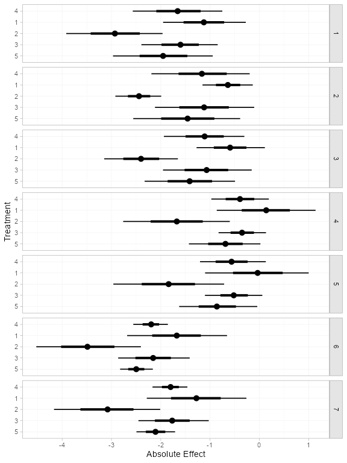

```r
plot(arm_pred_FE_studies)
```

We can also produce treatment rankings, rank probabilities, and cumulative rank probabilities.

```r
(arm_ranks <- posterior_ranks(arm_fit_FE))
```

```
#>         mean   sd 2.5% 25% 50% 75% 97.5% Bulk_ESS Tail_ESS Rhat
#> rank[4] 3.51 0.72    2   3   3   4     5     1946       NA    1
#> rank[1] 4.63 0.77    2   5   5   5     5     2089       NA    1
#> rank[2] 1.05 0.26    1   1   1   1     2     2382     2410    1
#> rank[3] 3.51 0.92    2   3   4   4     5     2355       NA    1
#> rank[5] 2.29 0.69    1   2   2   2     4     2180     2219    1
```

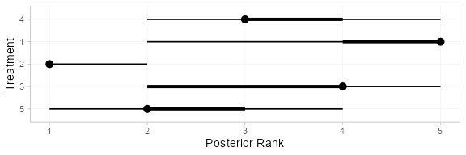

```r
plot(arm_ranks)
```

```r
(arm_rankprobs <- posterior_rank_probs(arm_fit_FE))
```

```
#>      p_rank[1] p_rank[2] p_rank[3] p_rank[4] p_rank[5]
#> d[4]      0.00      0.05      0.49      0.38      0.09
#> d[1]      0.00      0.04      0.07      0.12      0.78
#> d[2]      0.96      0.04      0.01      0.00      0.00
#> d[3]      0.00      0.17      0.26      0.44      0.12
#> d[5]      0.04      0.71      0.18      0.06      0.01
```

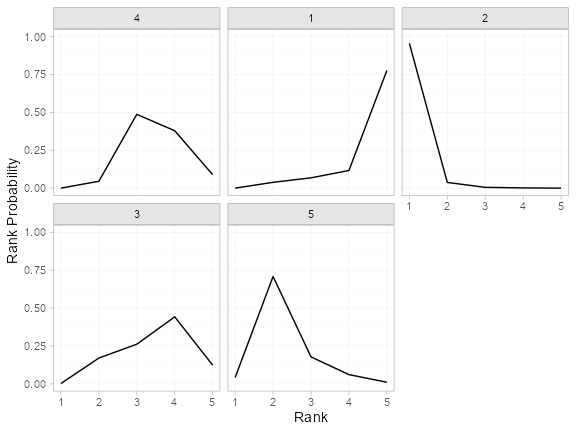

```r
plot(arm_rankprobs)
```

```r
(arm_cumrankprobs <- posterior_rank_probs(arm_fit_FE, cumulative = TRUE))
```

```
#>      p_rank[1] p_rank[2] p_rank[3] p_rank[4] p_rank[5]
#> d[4]      0.00      0.05      0.53      0.91         1
#> d[1]      0.00      0.04      0.11      0.22         1
#> d[2]      0.96      0.99      1.00      1.00         1
#> d[3]      0.00      0.17      0.43      0.88         1
#> d[5]      0.04      0.75      0.93      0.99         1
```

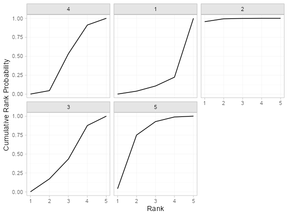

```r
plot(arm_cumrankprobs)
```

## Analysis of contrast-based data

We now perform an analysis using the contrast-based data (mean differences and standard errors).

### Setting up the network

With contrast-level data giving the mean difference in off-time reduction (`diff`) and standard error (`se_diff`), we use the function `set_agd_contrast()` to set up the network.

```r
contr_net <- set_agd_contrast(parkinsons,
                              study = studyn,
                              trt = trtn,
                              y = diff,
                              se = se_diff,
                              sample_size = n)
contr_net
```

```
#> A network with 7 AgD studies (contrast-based).
#>
#> -------------------------------------------------- AgD studies (contrast-based) ----
#>  Study Treatment arms
#>  1     2: 1 | 3
#>  2     2: 1 | 2
#>  3     3: 4 | 1 | 2
#>  4     2: 4 | 3
#>  5     2: 4 | 3
#>  6     2: 4 | 5
#>  7     2: 4 | 5
#>
#>  Outcome type: continuous
#> ------------------------------------------------------------------------------------
#> Total number of treatments: 5
#> Total number of studies: 7
#> Reference treatment is: 4
#> Network is connected
```

The `sample_size` argument is optional, but enables the nodes to be weighted by sample size in the network plot.

Plot the network structure.

```r
plot(contr_net, weight_edges = TRUE, weight_nodes = TRUE)
```

[output not shown]

### Meta-analysis models

We fit both fixed effect (FE) and random effects (RE) models.

#### Fixed effect meta-analysis

First, we fit a fixed effect model using the `nma()` function with `trt_effects = "fixed"`. We use $\mathrm{N}(0, 100^2)$ prior distributions for the treatment effects $d_k$. We can examine the range of parameter values implied by these prior distributions with the `summary()` method:

```r
summary(normal(scale = 100))
```

```
#> A Normal prior distribution: location = 0, scale = 100.
#> 50% of the prior density lies between -67.45 and 67.45.
#> 95% of the prior density lies between -196 and 196.
```

The model is fitted using the `nma()` function.

```r
contr_fit_FE <- nma(contr_net,
                    trt_effects = "fixed",
                    prior_trt = normal(scale = 100))
```

```
#> Note: Setting "4" as the network reference treatment.
```

Basic parameter summaries are given by the `print()` method:

```r
contr_fit_FE
```

```
#> A fixed effects NMA with a normal likelihood (identity link).
#> Inference for Stan model: normal.
#> 4 chains, each with iter=2000; warmup=1000; thin=1;
#> post-warmup draws per chain=1000, total post-warmup draws=4000.
#>
#>       mean se_mean   sd  2.5%   25%   50%   75% 97.5% n_eff Rhat
#> d[1]  0.52    0.01 0.48 -0.43  0.18  0.53  0.85  1.44  2039    1
#> d[2] -1.30    0.01 0.53 -2.32 -1.65 -1.29 -0.94 -0.28  2133    1
#> d[3]  0.05    0.01 0.33 -0.62 -0.17  0.05  0.27  0.70  3049    1
#> d[5] -0.30    0.00 0.21 -0.71 -0.45 -0.30 -0.16  0.10  3069    1
#> lp__ -3.19    0.04 1.46 -6.82 -3.90 -2.84 -2.12 -1.42  1737    1
#>
#> Samples were drawn using NUTS(diag_e) at Mon Apr 29 16:40:20 2024.
#> For each parameter, n_eff is a crude measure of effective sample size,
#> and Rhat is the potential scale reduction factor on split chains (at
#> convergence, Rhat=1).
```

The prior and posterior distributions can be compared visually using the `plot_prior_posterior()` function:

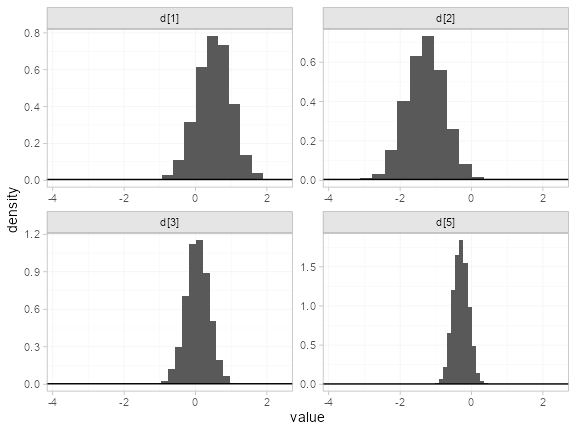

```r
plot_prior_posterior(contr_fit_FE)
```

#### Random effects meta-analysis

We now fit a random effects model using the `nma()` function with `trt_effects = "random"`. Again, we use $\mathrm{N}(0, 100^2)$ prior distributions for the treatment effects $d_k$, and we additionally use a $\textrm{half-N}(5^2)$ prior for the heterogeneity standard deviation $\tau$. We can examine the range of parameter values implied by these prior distributions with the `summary()` method:

```r
summary(normal(scale = 100))
```

```
#> A Normal prior distribution: location = 0, scale = 100.
#> 50% of the prior density lies between -67.45 and 67.45.
#> 95% of the prior density lies between -196 and 196.
```

```r
summary(half_normal(scale = 5))
```

```
#> A half-Normal prior distribution: location = 0, scale = 5.
#> 50% of the prior density lies between 0 and 3.37.
#> 95% of the prior density lies between 0 and 9.8.
```

Fitting the RE model

```r
contr_fit_RE <- nma(contr_net,
                    seed = 1150676438,
                    trt_effects = "random",
                    prior_trt = normal(scale = 100),
                    prior_het = half_normal(scale = 5),
                    adapt_delta = 0.99)
```

```
#> Note: Setting "4" as the network reference treatment.
#> Warning: There were 5 divergent transitions after warmup. See
#> https://mc-stan.org/misc/warnings.html#divergent-transitions-after-warmup
#> to find out why this is a problem and how to eliminate them.
#> Warning: Examine the pairs() plot to diagnose sampling problems
```

We do see a small number of divergent transition errors, which cannot simply be removed by increasing the value of the `adapt_delta` argument (by default set to `0.95` for RE models). To diagnose, we use the `pairs()` method to investigate where in the posterior distribution these divergences are happening (indicated by red crosses):

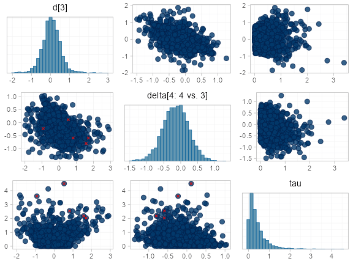

```r
pairs(contr_fit_RE, pars = c("d[3]", "delta[4: 4 vs. 3]", "tau"))
```

The divergent transitions occur in the upper tail of the heterogeneity standard deviation. In this case, with only a small number of studies, there is not very much information to estimate the heterogeneity standard deviation and the prior distribution may be too heavy-tailed. We could consider a more informative prior distribution for the heterogeneity variance to aid estimation.

Basic parameter summaries are given by the `print()` method:

```r
contr_fit_RE
```

```
#> A random effects NMA with a normal likelihood (identity link).
#> Inference for Stan model: normal.
#> 4 chains, each with iter=2000; warmup=1000; thin=1;
#> post-warmup draws per chain=1000, total post-warmup draws=4000.
#>
#>       mean se_mean   sd   2.5%   25%   50%   75% 97.5% n_eff Rhat
#> d[1]  0.53    0.02 0.74  -0.76  0.13  0.52  0.93  1.85  1349 1.00
#> d[2] -1.32    0.02 0.75  -2.75 -1.73 -1.32 -0.90  0.08  1655 1.00
#> d[3]  0.05    0.01 0.50  -0.93 -0.24  0.04  0.33  1.08  2018 1.00
#> d[5] -0.30    0.01 0.49  -1.18 -0.52 -0.31 -0.10  0.67  1461 1.00
#> lp__ -8.15    0.08 2.80 -14.25 -9.84 -7.89 -6.17 -3.37  1259 1.00
#> tau   0.42    0.02 0.45   0.02  0.13  0.29  0.55  1.67   493 1.01
#>
#> Samples were drawn using NUTS(diag_e) at Mon Apr 29 16:40:30 2024.
#> For each parameter, n_eff is a crude measure of effective sample size,
#> and Rhat is the potential scale reduction factor on split chains (at
#> convergence, Rhat=1).
```

By default, summaries of the study-specific relative effects $\delta_{jk}$ are hidden, but could be examined by changing the `pars` argument:

```r
# Not run
print(contr_fit_RE, pars = c("d", "delta"))
```

The prior and posterior distributions can be compared visually using the `plot_prior_posterior()` function:

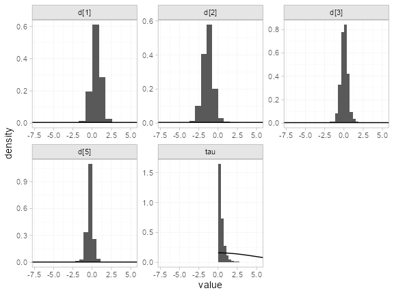

```r
plot_prior_posterior(contr_fit_RE)
```

#### Model comparison

Model fit can be checked using the `dic()` function:

```r
(contr_dic_FE <- dic(contr_fit_FE))
```

```
#> Residual deviance: 6.4 (on 8 data points)
#>                pD: 4.1
#>               DIC: 10.5
```

```r
(contr_dic_RE <- dic(contr_fit_RE))
```

```
#> Residual deviance: 6.6 (on 8 data points)
#>                pD: 5.4
#>               DIC: 12
```

Both models fit the data well, having posterior mean residual deviance close to the number of data points. The DIC is similar between models, so we choose the FE model based on parsimony.

We can also examine the residual deviance contributions with the corresponding `plot()` method.

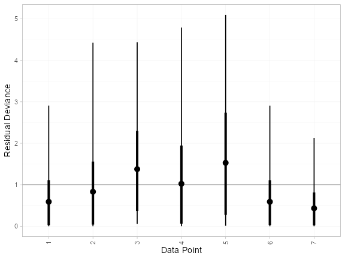

```r
plot(contr_dic_FE)
```

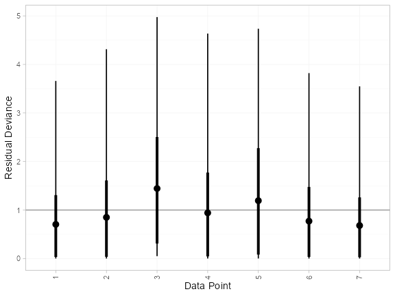

```r
plot(contr_dic_RE)
```

### Further results

For comparison with Dias et al. (2011), we can produce relative effects against placebo using the `relative_effects()` function with `trt_ref = 1`:

```r
(contr_releff_FE <- relative_effects(contr_fit_FE, trt_ref = 1))
```

```
#>       mean   sd  2.5%   25%   50%   75% 97.5% Bulk_ESS Tail_ESS Rhat
#> d[4] -0.52 0.48 -1.44 -0.85 -0.53 -0.18  0.43     2058     2033    1
#> d[2] -1.81 0.33 -2.47 -2.03 -1.81 -1.59 -1.16     4970     3270    1
#> d[3] -0.47 0.49 -1.41 -0.79 -0.47 -0.15  0.53     2877     2737    1
#> d[5] -0.82 0.53 -1.88 -1.19 -0.82 -0.45  0.22     2169     2082    1
```

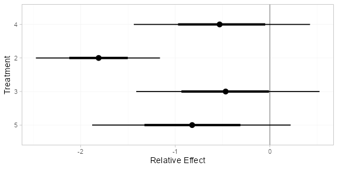

```r
plot(contr_releff_FE, ref_line = 0)
```

```r
(contr_releff_RE <- relative_effects(contr_fit_RE, trt_ref = 1))
```

```
#>       mean   sd  2.5%   25%   50%   75% 97.5% Bulk_ESS Tail_ESS Rhat
#> d[4] -0.53 0.74 -1.85 -0.93 -0.52 -0.13  0.76     1918     1301    1
#> d[2] -1.85 0.53 -2.94 -2.14 -1.85 -1.55 -0.83     2862     1173    1
#> d[3] -0.48 0.72 -1.83 -0.89 -0.49 -0.09  0.90     2249     1142    1
#> d[5] -0.83 0.96 -2.41 -1.29 -0.84 -0.37  0.70     1971     1443    1
```

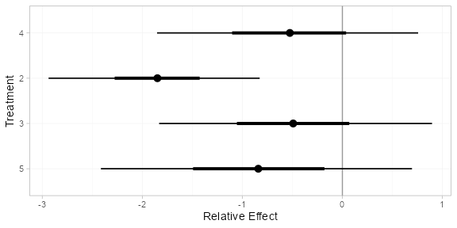

```r
plot(contr_releff_RE, ref_line = 0)
```

Following Dias et al. (2011), we produce absolute predictions of the mean off-time reduction on each treatment assuming a Normal distribution for the outcomes on treatment 1 (placebo) with mean $-0.73$ and precision $21$. We use the `predict()` method, where the `baseline` argument takes a `distr()` distribution object with which we specify the corresponding Normal distribution, and we specify `baseline_trt = 1` to indicate that the baseline distribution corresponds to treatment 1. (Strictly speaking, `type = "response"` is unnecessary here, since the identity link function was used.)

```r
contr_pred_FE <- predict(contr_fit_FE,
                       baseline = distr(qnorm, mean = -0.73, sd = 21^-0.5),
                       type = "response",
                       baseline_trt = 1)
contr_pred_FE
```

```
#>          mean   sd  2.5%   25%   50%   75% 97.5% Bulk_ESS Tail_ESS Rhat
#> pred[4] -1.25 0.53 -2.29 -1.61 -1.25 -0.88 -0.20     2225     2535    1
#> pred[1] -0.73 0.22 -1.16 -0.88 -0.73 -0.58 -0.30     3988     3629    1
#> pred[2] -2.54 0.40 -3.32 -2.81 -2.55 -2.27 -1.76     4703     3604    1
#> pred[3] -1.20 0.53 -2.23 -1.56 -1.19 -0.83 -0.16     2933     3110    1
#> pred[5] -1.55 0.58 -2.68 -1.94 -1.56 -1.16 -0.45     2319     2379    1
```

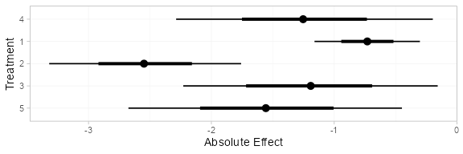

```r
plot(contr_pred_FE)
```

```r
contr_pred_RE <- predict(contr_fit_RE,
                       baseline = distr(qnorm, mean = -0.73, sd = 21^-0.5),
                       type = "response",
                       baseline_trt = 1)
contr_pred_RE
```

```
#>          mean   sd  2.5%   25%   50%   75% 97.5% Bulk_ESS Tail_ESS Rhat
#> pred[4] -1.26 0.77 -2.67 -1.68 -1.27 -0.84  0.12     1995     1516    1
#> pred[1] -0.73 0.22 -1.16 -0.88 -0.73 -0.59 -0.31     3715     3592    1
#> pred[2] -2.58 0.57 -3.75 -2.91 -2.58 -2.25 -1.46     2808     1235    1
#> pred[3] -1.21 0.75 -2.62 -1.66 -1.23 -0.80  0.22     2275     1195    1
#> pred[5] -1.56 0.98 -3.17 -2.06 -1.57 -1.09  0.05     2050     1535    1
```

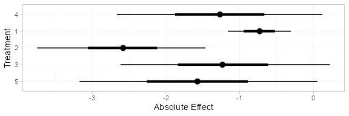

```r
plot(contr_pred_RE)
```

If the `baseline` argument is omitted an error will be raised, as there are no study baselines estimated in this network.

```r
# Not run
predict(contr_fit_FE, type = "response")
```

We can also produce treatment rankings, rank probabilities, and cumulative rank probabilities.

```r
(contr_ranks <- posterior_ranks(contr_fit_FE))
```

```
#>         mean   sd 2.5% 25% 50% 75% 97.5% Bulk_ESS Tail_ESS Rhat
#> rank[4] 3.50 0.72    2   3   3   4     5     2582       NA    1
#> rank[1] 4.63 0.78    2   5   5   5     5     2109       NA    1
#> rank[2] 1.06 0.28    1   1   1   1     2     2410     2472    1
#> rank[3] 3.53 0.92    2   3   4   4     5     3405       NA    1
#> rank[5] 2.28 0.67    1   2   2   2     4     2284     2190    1
```

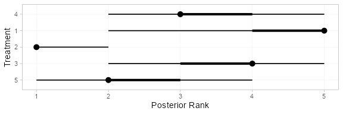

```r
plot(contr_ranks)
```

```r
(contr_rankprobs <- posterior_rank_probs(contr_fit_FE))
```

```
#>      p_rank[1] p_rank[2] p_rank[3] p_rank[4] p_rank[5]
#> d[4]      0.00      0.05      0.48      0.38      0.08
#> d[1]      0.00      0.04      0.07      0.12      0.78
#> d[2]      0.96      0.04      0.01      0.00      0.00
#> d[3]      0.00      0.16      0.26      0.45      0.13
#> d[5]      0.04      0.72      0.18      0.05      0.01
```

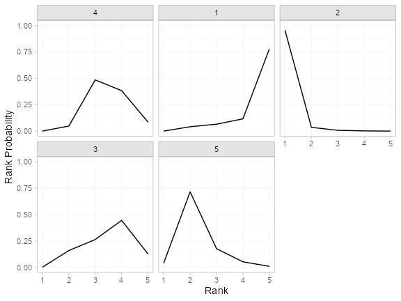

```r
plot(contr_rankprobs)
```

```r
(contr_cumrankprobs <- posterior_rank_probs(contr_fit_FE, cumulative = TRUE))
```

```
#>      p_rank[1] p_rank[2] p_rank[3] p_rank[4] p_rank[5]
#> d[4]      0.00      0.05      0.53      0.92         1
#> d[1]      0.00      0.04      0.11      0.22         1
#> d[2]      0.96      0.99      1.00      1.00         1
#> d[3]      0.00      0.16      0.43      0.87         1
#> d[5]      0.04      0.76      0.94      0.99         1
```

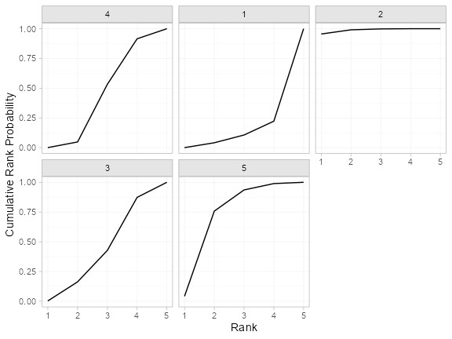

```r
plot(contr_cumrankprobs)
```

## Analysis of mixed arm-based and contrast-based data

We now perform an analysis where some studies contribute arm-based data, and other contribute contrast-based data. Replicating Dias et al. (2011), we consider arm-based data from studies 1-3, and contrast-based data from studies 4-7.

```r
studies <- parkinsons$studyn
(parkinsons_arm <- parkinsons[studies %in% 1:3, ])
```

```
#>   studyn trtn     y    se   n  diff se_diff
#> 1      1    1 -1.22 0.504  54    NA   0.504
#> 2      1    3 -1.53 0.439  95 -0.31   0.668
#> 3      2    1 -0.70 0.282 172    NA   0.282
#> 4      2    2 -2.40 0.258 173 -1.70   0.382
#> 5      3    1 -0.30 0.505  76    NA   0.505
#> 6      3    2 -2.60 0.510  71 -2.30   0.718
#> 7      3    4 -1.20 0.478  81 -0.90   0.695
```

```r
(parkinsons_contr <- parkinsons[studies %in% 4:7, ])
```

```
#>    studyn trtn     y    se   n  diff se_diff
#> 8       4    3 -0.24 0.265 128    NA   0.265
#> 9       4    4 -0.59 0.354  72 -0.35   0.442
#> 10      5    3 -0.73 0.335  80    NA   0.335
#> 11      5    4 -0.18 0.442  46  0.55   0.555
#> 12      6    4 -2.20 0.197 137    NA   0.197
#> 13      6    5 -2.50 0.190 131 -0.30   0.274
#> 14      7    4 -1.80 0.200 154    NA   0.200
#> 15      7    5 -2.10 0.250 143 -0.30   0.320
```

### Setting up the network

We use the functions `set_agd_arm()` and `set_agd_contrast()` to set up the respective data sources within the network, and then combine together with `combine_network()`.

```r
mix_arm_net <- set_agd_arm(parkinsons_arm,
                           study = studyn,
                           trt = trtn,
                           y = y,
                           se = se,
                           sample_size = n)

mix_contr_net <- set_agd_contrast(parkinsons_contr,
                                  study = studyn,
                                  trt = trtn,
                                  y = diff,
                                  se = se_diff,
                                  sample_size = n)

mix_net <- combine_network(mix_arm_net, mix_contr_net)
mix_net
```

```
#> A network with 3 AgD studies (arm-based), and 4 AgD studies (contrast-based).
#>
#> ------------------------------------------------------- AgD studies (arm-based) ----
#>  Study Treatment arms
#>  1     2: 1 | 3
#>  2     2: 1 | 2
#>  3     3: 4 | 1 | 2
#>
#>  Outcome type: continuous
#> -------------------------------------------------- AgD studies (contrast-based) ----
#>  Study Treatment arms
#>  4     2: 4 | 3
#>  5     2: 4 | 3
#>  6     2: 4 | 5
#>  7     2: 4 | 5
#>
#>  Outcome type: continuous
#> ------------------------------------------------------------------------------------
#> Total number of treatments: 5
#> Total number of studies: 7
#> Reference treatment is: 4
#> Network is connected
```

The `sample_size` argument is optional, but enables the nodes to be weighted by sample size in the network plot.

Plot the network structure.

```r
plot(mix_net, weight_edges = TRUE, weight_nodes = TRUE)
```

[output not shown]

### Meta-analysis models

We fit both fixed effect (FE) and random effects (RE) models.

#### Fixed effect meta-analysis

First, we fit a fixed effect model using the `nma()` function with `trt_effects = "fixed"`. We use $\mathrm{N}(0, 100^2)$ prior distributions for the treatment effects $d_k$ and study-specific intercepts $\mu_j$. We can examine the range of parameter values implied by these prior distributions with the `summary()` method:

```r
summary(normal(scale = 100))
```

```
#> A Normal prior distribution: location = 0, scale = 100.
#> 50% of the prior density lies between -67.45 and 67.45.
#> 95% of the prior density lies between -196 and 196.
```

The model is fitted using the `nma()` function.

```r
mix_fit_FE <- nma(mix_net,
                  trt_effects = "fixed",
                  prior_intercept = normal(scale = 100),
                  prior_trt = normal(scale = 100))
```

```
#> Note: Setting "4" as the network reference treatment.
```

Basic parameter summaries are given by the `print()` method:

```r
mix_fit_FE
```

```
#> A fixed effects NMA with a normal likelihood (identity link).
#> Inference for Stan model: normal.
#> 4 chains, each with iter=2000; warmup=1000; thin=1;
#> post-warmup draws per chain=1000, total post-warmup draws=4000.
#>
#>       mean se_mean   sd  2.5%   25%   50%   75% 97.5% n_eff Rhat
#> d[1]  0.54    0.01 0.50 -0.45  0.20  0.53  0.87  1.52  1351    1
#> d[2] -1.27    0.01 0.53 -2.33 -1.62 -1.27 -0.92 -0.21  1452    1
#> d[3]  0.05    0.01 0.33 -0.56 -0.16  0.05  0.27  0.70  2384    1
#> d[5] -0.29    0.00 0.20 -0.68 -0.42 -0.29 -0.16  0.11  3047    1
#> lp__ -4.69    0.05 1.94 -9.39 -5.70 -4.36 -3.26 -1.99  1589    1
#>
#> Samples were drawn using NUTS(diag_e) at Mon Apr 29 16:40:45 2024.
#> For each parameter, n_eff is a crude measure of effective sample size,
#> and Rhat is the potential scale reduction factor on split chains (at
#> convergence, Rhat=1).
```

By default, summaries of the study-specific intercepts $\mu_j$ are hidden, but could be examined by changing the `pars` argument:

```r
# Not run
print(mix_fit_FE, pars = c("d", "mu"))
```

The prior and posterior distributions can be compared visually using the `plot_prior_posterior()` function:

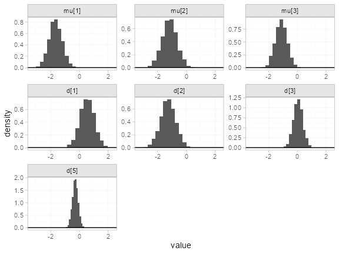

```r
plot_prior_posterior(mix_fit_FE)
```

#### Random effects meta-analysis

We now fit a random effects model using the `nma()` function with `trt_effects = "random"`. Again, we use $\mathrm{N}(0, 100^2)$ prior distributions for the treatment effects $d_k$ and study-specific intercepts $\mu_j$, and we additionally use a $\textrm{half-N}(5^2)$ prior for the heterogeneity standard deviation $\tau$. We can examine the range of parameter values implied by these prior distributions with the `summary()` method:

```r
summary(normal(scale = 100))
```

```
#> A Normal prior distribution: location = 0, scale = 100.
#> 50% of the prior density lies between -67.45 and 67.45.
#> 95% of the prior density lies between -196 and 196.
```

```r
summary(half_normal(scale = 5))
```

```
#> A half-Normal prior distribution: location = 0, scale = 5.
#> 50% of the prior density lies between 0 and 3.37.
#> 95% of the prior density lies between 0 and 9.8.
```

Fitting the RE model

```r
mix_fit_RE <- nma(mix_net,
                  seed = 437219664,
                  trt_effects = "random",
                  prior_intercept = normal(scale = 100),
                  prior_trt = normal(scale = 100),
                  prior_het = half_normal(scale = 5),
                  adapt_delta = 0.99)
```

```
#> Note: Setting "4" as the network reference treatment.
#> Warning: There were 1 divergent transitions after warmup. See
#> https://mc-stan.org/misc/warnings.html#divergent-transitions-after-warmup
#> to find out why this is a problem and how to eliminate them.
#> Warning: Examine the pairs() plot to diagnose sampling problems
```

We do see a small number of divergent transition errors, which cannot simply be removed by increasing the value of the `adapt_delta` argument (by default set to `0.95` for RE models). To diagnose, we use the `pairs()` method to investigate where in the posterior distribution these divergences are happening (indicated by red crosses):

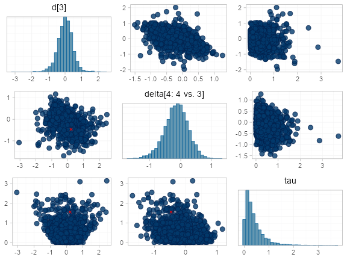

```r
pairs(mix_fit_RE, pars = c("d[3]", "delta[4: 4 vs. 3]", "tau"))
```

The divergent transitions occur in the upper tail of the heterogeneity standard deviation. In this case, with only a small number of studies, there is not very much information to estimate the heterogeneity standard deviation and the prior distribution may be too heavy-tailed. We could consider a more informative prior distribution for the heterogeneity variance to aid estimation.

Basic parameter summaries are given by the `print()` method:

```r
mix_fit_RE
```

```
#> A random effects NMA with a normal likelihood (identity link).
#> Inference for Stan model: normal.
#> 4 chains, each with iter=2000; warmup=1000; thin=1;
#> post-warmup draws per chain=1000, total post-warmup draws=4000.
#>
#>        mean se_mean   sd   2.5%    25%    50%   75% 97.5% n_eff Rhat
#> d[1]   0.54    0.01 0.62  -0.70   0.16   0.54  0.93  1.74  2026 1.00
#> d[2]  -1.30    0.02 0.69  -2.71  -1.72  -1.29 -0.87  0.02  2090 1.00
#> d[3]   0.01    0.01 0.47  -0.95  -0.26   0.02  0.30  0.90  2852 1.00
#> d[5]  -0.29    0.01 0.42  -1.14  -0.50  -0.30 -0.09  0.53  2405 1.00
#> lp__ -10.64    0.09 3.25 -17.61 -12.61 -10.33 -8.33 -5.14  1183 1.00
#> tau    0.39    0.01 0.38   0.02   0.13   0.29  0.53  1.42   646 1.01
#>
#> Samples were drawn using NUTS(diag_e) at Mon Apr 29 16:40:57 2024.
#> For each parameter, n_eff is a crude measure of effective sample size,
#> and Rhat is the potential scale reduction factor on split chains (at
#> convergence, Rhat=1).
```

By default, summaries of the study-specific intercepts $\mu_j$ and study-specific relative effects $\delta_{jk}$ are hidden, but could be examined by changing the `pars` argument:

```r
# Not run
print(mix_fit_RE, pars = c("d", "mu", "delta"))
```

The prior and posterior distributions can be compared visually using the `plot_prior_posterior()` function:

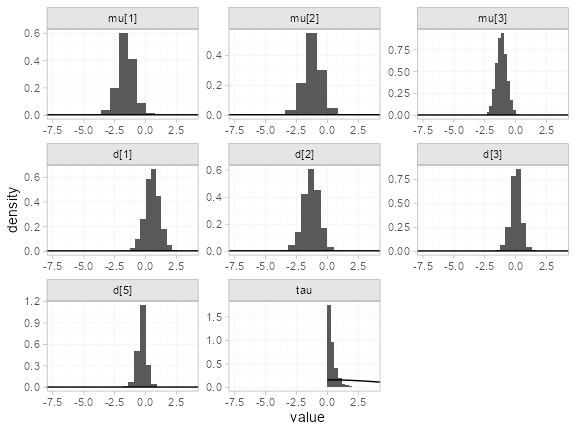

```r
plot_prior_posterior(mix_fit_RE)
```

#### Model comparison

Model fit can be checked using the `dic()` function:

```r
(mix_dic_FE <- dic(mix_fit_FE))
```

```
#> Residual deviance: 9.4 (on 11 data points)
#>                pD: 7.1
#>               DIC: 16.5
```

```r
(mix_dic_RE <- dic(mix_fit_RE))
```

```
#> Residual deviance: 9.5 (on 11 data points)
#>                pD: 8.4
#>               DIC: 17.9
```

Both models fit the data well, having posterior mean residual deviance close to the number of data points. The DIC is similar between models, so we choose the FE model based on parsimony.

We can also examine the residual deviance contributions with the corresponding `plot()` method.

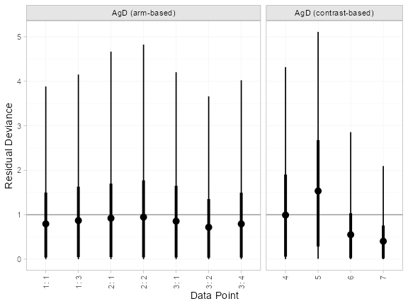

```r
plot(mix_dic_FE)
```

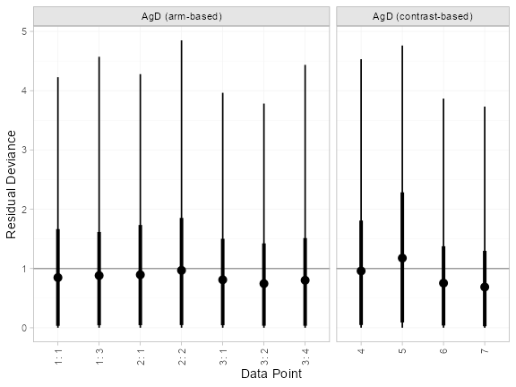

```r
plot(mix_dic_RE)
```

### Further results

For comparison with Dias et al. (2011), we can produce relative effects against placebo using the `relative_effects()` function with `trt_ref = 1`:

```r
(mix_releff_FE <- relative_effects(mix_fit_FE, trt_ref = 1))
```

```
#>       mean   sd  2.5%   25%   50%   75% 97.5% Bulk_ESS Tail_ESS Rhat
#> d[4] -0.54 0.50 -1.52 -0.87 -0.53 -0.20  0.45     1362     1865    1
#> d[2] -1.81 0.34 -2.49 -2.03 -1.80 -1.58 -1.13     5688     3158    1
#> d[3] -0.48 0.50 -1.45 -0.82 -0.48 -0.14  0.48     2201     2871    1
#> d[5] -0.83 0.53 -1.89 -1.18 -0.84 -0.47  0.23     1471     2375    1
```

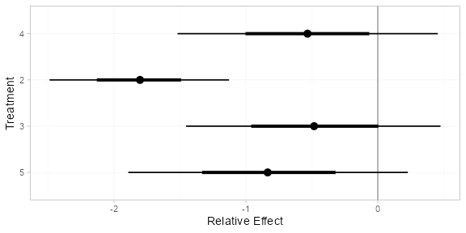

```r
plot(mix_releff_FE, ref_line = 0)
```

```r
(mix_releff_RE <- relative_effects(mix_fit_RE, trt_ref = 1))
```

```
#>       mean   sd  2.5%   25%   50%   75% 97.5% Bulk_ESS Tail_ESS Rhat
#> d[4] -0.54 0.62 -1.74 -0.93 -0.54 -0.16  0.70     2009     2208    1
#> d[2] -1.83 0.50 -2.84 -2.13 -1.83 -1.54 -0.83     4185     2461    1
#> d[3] -0.53 0.64 -1.81 -0.90 -0.53 -0.14  0.73     2992     2498    1
#> d[5] -0.83 0.75 -2.36 -1.28 -0.83 -0.40  0.74     2220     1883    1
```

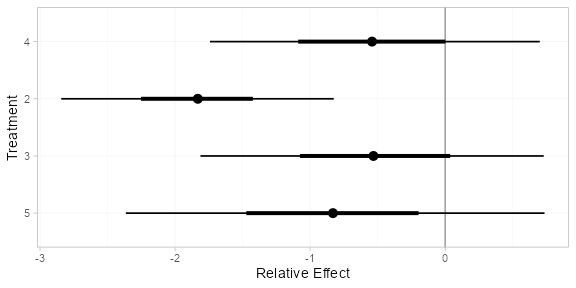

```r
plot(mix_releff_RE, ref_line = 0)
```

Following Dias et al. (2011), we produce absolute predictions of the mean off-time reduction on each treatment assuming a Normal distribution for the outcomes on treatment 1 (placebo) with mean $-0.73$ and precision $21$. We use the `predict()` method, where the `baseline` argument takes a `distr()` distribution object with which we specify the corresponding Normal distribution, and we specify `baseline_trt = 1` to indicate that the baseline distribution corresponds to treatment 1. (Strictly speaking, `type = "response"` is unnecessary here, since the identity link function was used.)

```r
mix_pred_FE <- predict(mix_fit_FE,
                       baseline = distr(qnorm, mean = -0.73, sd = 21^-0.5),
                       type = "response",
                       baseline_trt = 1)
mix_pred_FE
```

```
#>          mean   sd  2.5%   25%   50%   75% 97.5% Bulk_ESS Tail_ESS Rhat
#> pred[4] -1.26 0.54 -2.28 -1.62 -1.26 -0.90 -0.20     1437     2402    1
#> pred[1] -0.72 0.22 -1.14 -0.87 -0.72 -0.58 -0.29     3556     3638    1
#> pred[2] -2.53 0.40 -3.33 -2.79 -2.53 -2.25 -1.78     4946     3640    1
#> pred[3] -1.20 0.54 -2.24 -1.56 -1.21 -0.83 -0.14     2203     2910    1
#> pred[5] -1.55 0.57 -2.67 -1.93 -1.56 -1.16 -0.43     1532     2360    1
```

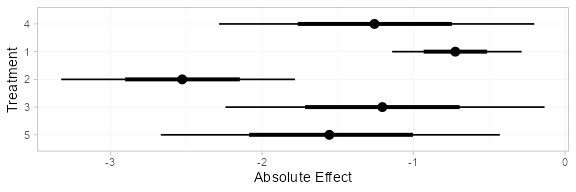

```r
plot(mix_pred_FE)
```

```r
mix_pred_RE <- predict(mix_fit_RE,
                       baseline = distr(qnorm, mean = -0.73, sd = 21^-0.5),
                       type = "response",
                       baseline_trt = 1)
mix_pred_RE
```

```
#>          mean   sd  2.5%   25%   50%   75% 97.5% Bulk_ESS Tail_ESS Rhat
#> pred[4] -1.27 0.66 -2.55 -1.69 -1.26 -0.86  0.04     2089     2170    1
#> pred[1] -0.73 0.22 -1.17 -0.88 -0.73 -0.58 -0.31     4051     3817    1
#> pred[2] -2.56 0.55 -3.68 -2.90 -2.56 -2.22 -1.47     4127     2529    1
#> pred[3] -1.25 0.67 -2.60 -1.67 -1.26 -0.84  0.06     3027     2404    1
#> pred[5] -1.56 0.78 -3.19 -2.03 -1.55 -1.10  0.02     2234     2132    1
```

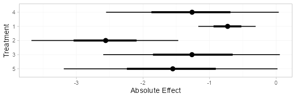

```r
plot(mix_pred_RE)
```

If the `baseline` argument is omitted, predictions of mean off-time reduction will be produced for every *arm-based* study in the network based on their estimated baseline response $\mu_j$:

```r
mix_pred_FE_studies <- predict(mix_fit_FE, type = "response")
mix_pred_FE_studies
```

```
#> ---------------------------------------------------------------------- Study: 1 ----
#>
#>             mean   sd  2.5%   25%   50%   75% 97.5% Bulk_ESS Tail_ESS Rhat
#> pred[1: 4] -1.66 0.46 -2.59 -1.96 -1.67 -1.34 -0.76     1906     2750    1
#> pred[1: 1] -1.13 0.44 -1.99 -1.42 -1.12 -0.83 -0.27     3421     3183    1
#> pred[1: 2] -2.93 0.52 -3.96 -3.29 -2.93 -2.58 -1.90     3322     2785    1
#> pred[1: 3] -1.61 0.40 -2.39 -1.88 -1.61 -1.33 -0.83     3506     3107    1
#> pred[1: 5] -1.95 0.51 -2.97 -2.28 -1.95 -1.62 -0.96     2057     2618    1
#>
#> ---------------------------------------------------------------------- Study: 2 ----
#>
#>             mean   sd  2.5%   25%   50%   75% 97.5% Bulk_ESS Tail_ESS Rhat
#> pred[2: 4] -1.18 0.53 -2.23 -1.53 -1.18 -0.83 -0.15     1384     2051    1
#> pred[2: 1] -0.64 0.26 -1.15 -0.82 -0.64 -0.47 -0.12     4802     3488    1
#> pred[2: 2] -2.45 0.25 -2.93 -2.61 -2.45 -2.29 -1.96     4260     3056    1
#> pred[2: 3] -1.13 0.54 -2.16 -1.49 -1.12 -0.77 -0.06     2016     2729    1
#> pred[2: 5] -1.47 0.56 -2.57 -1.84 -1.48 -1.09 -0.37     1495     2249    1
#>
#> ---------------------------------------------------------------------- Study: 3 ----
#>
#>             mean   sd  2.5%   25%   50%   75% 97.5% Bulk_ESS Tail_ESS Rhat
#> pred[3: 4] -1.13 0.42 -1.93 -1.41 -1.12 -0.85 -0.30     1680     2691    1
#> pred[3: 1] -0.59 0.36 -1.33 -0.83 -0.58 -0.35  0.09     3847     3220    1
#> pred[3: 2] -2.40 0.38 -3.16 -2.65 -2.40 -2.15 -1.63     4053     3307    1
#> pred[3: 3] -1.07 0.46 -1.98 -1.38 -1.07 -0.76 -0.16     2690     2739    1
#> pred[3: 5] -1.42 0.47 -2.33 -1.74 -1.41 -1.10 -0.52     1942     2711    1
```

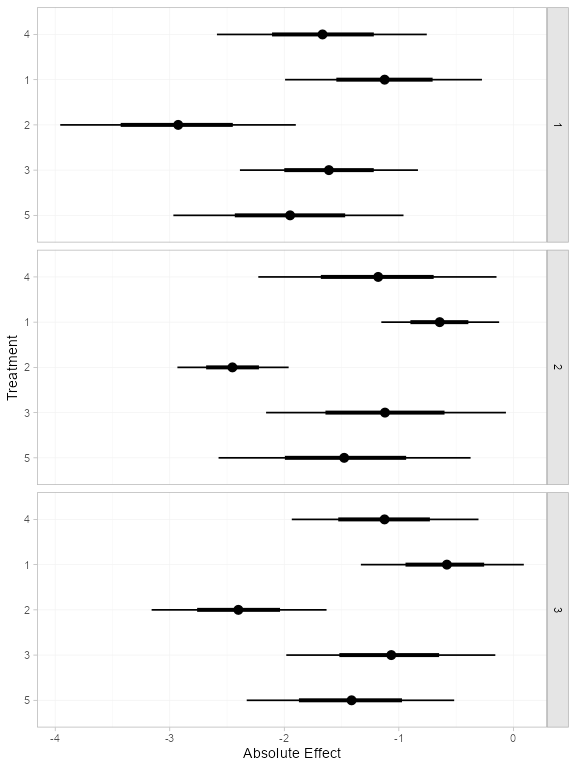

```r
plot(mix_pred_FE_studies)
```

We can also produce treatment rankings, rank probabilities, and cumulative rank probabilities.

```r
(mix_ranks <- posterior_ranks(mix_fit_FE))
```

```
#>         mean   sd 2.5% 25% 50% 75% 97.5% Bulk_ESS Tail_ESS Rhat
#> rank[4] 3.49 0.71    2   3   3   4     5     2091       NA    1
#> rank[1] 4.63 0.79    2   5   5   5     5     2052       NA    1
#> rank[2] 1.06 0.29    1   1   1   1     2     2240     2381    1
#> rank[3] 3.54 0.93    2   3   4   4     5     2898       NA    1
#> rank[5] 2.28 0.67    1   2   2   2     4     2131     2344    1
```

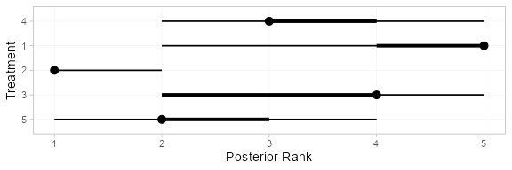

```r
plot(mix_ranks)
```

```r
(mix_rankprobs <- posterior_rank_probs(mix_fit_FE))
```

```
#>      p_rank[1] p_rank[2] p_rank[3] p_rank[4] p_rank[5]
#> d[4]      0.00      0.04      0.51      0.37      0.08
#> d[1]      0.00      0.05      0.06      0.11      0.78
#> d[2]      0.95      0.04      0.01      0.00      0.00
#> d[3]      0.00      0.17      0.24      0.46      0.13
#> d[5]      0.04      0.71      0.18      0.05      0.01
```

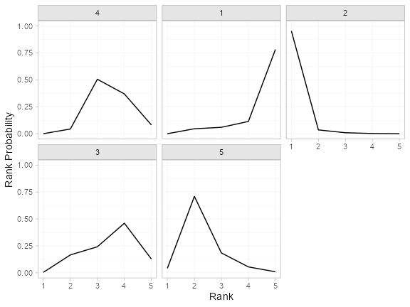

```r
plot(mix_rankprobs)
```

```r
(mix_cumrankprobs <- posterior_rank_probs(mix_fit_FE, cumulative = TRUE))
```

```
#>      p_rank[1] p_rank[2] p_rank[3] p_rank[4] p_rank[5]
#> d[4]      0.00      0.04      0.55      0.92         1
#> d[1]      0.00      0.05      0.10      0.22         1
#> d[2]      0.95      0.99      1.00      1.00         1
#> d[3]      0.00      0.17      0.41      0.87         1
#> d[5]      0.04      0.75      0.94      0.99         1
```

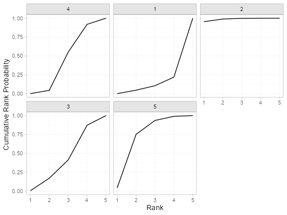

```r
plot(mix_cumrankprobs)
```

## References

Dias, S., N. J. Welton, A. J. Sutton, and A. E. Ades. 2011. “NICE DSU Technical Support Document 2: A Generalised Linear Modelling Framework for Pair-Wise and Network Meta-Analysis of Randomised Controlled Trials.” National Institute for Health and Care Excellence. https://sheffield.ac.uk/nice-dsu.